# Climates

BIOL 350, California State University-Long Beach, Fall 2019

Climate is the long-term description of weather, the latter defined by the atmospheric condition regarding heat, humidity, sunshine, wind, rain at a particular time and location. As organisms experience these atmospheric factors daily, climate shapes where and how organisms live. Thus, understanding how do physical principles influence the global climate is key to describe, predict and model phenomena in nature.  
The main objectives for today are to:

- Understand the relationship between insolation (the solar radiation that reaches the Earth’s surface) and global temperatures
- Understand why global temperatures vary across latitude
- Carry out and interprete correlation analysis

Resources:

- [NASA Surface meteorology and Solar Energy database](https://power.larc.nasa.gov/data-access-viewer/)

Datasets (to download, Save As Page Source):

- [insol_temp](https://raisahernandez.github.io/General-Ecology/insol_temp.csv)

**Part I: Solar radiation and global temperatures**

Step 1. Import the data to RStudio

```r
insol_temp <- read.csv("insol_temp.csv", header=TRUE)
```

Note that negative latitudes represent the southern hemisphere (S) and positive latitudes represent the northern hemisphere (N).

> **Question 1:** How many observations and variables each dataframe has?

Step 2. Explore (plot) the insolation data in relation to latitude

Let’s plot the data using basic R. For this, use the function plot(). The first argument is the independent variable and the secnd argument is the dependet variable. Note that you can use a dollar sign $ to indicate “within”.

```r
plot(insol_temp$lat,insol_temp$insol)
```

[output not shown]

```r
# Adding axes titles
plot(insol_temp$lat,insol_temp$insol,ylab="Insolation",xlab="Latitude")
```

[output not shown]

> **Question 1:** Is there a general pattern? Describe it.

Step 3. Explore the temperature data in relation to latitude

> **Challenge:** Following Step 2, plot the temperature data in relation to latitude.

> **Question 1:** After exploring both datasets, insolation and temperature across latitudes, predict the relationship between temperature and insolation.

Step 4. Correlation analysis between insolation and temperature

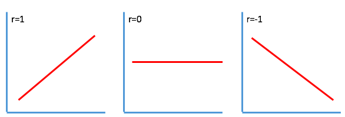

Let’s check whether temperature and insolation correlate!

```r
plot(insol_temp$insol,insol_temp$temp,ylab="Temperature (°C)",xlab="Insolation")
```

[output not shown]

The R function cor() estimates the correlation coefficient r with the formula below.

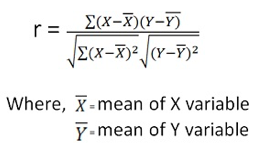

Go ahead and do a correlation analysis for insolation and temperature using the function cor(). The first argument is variable 1 (e.g., insol) and the second argument is variable 2 (e.g., temp). Note that you can use a dollar sign $ to indicate “within”.

```r
# Correlation analysis
cor(insol_temp$insol,insol_temp$temp)
```

[output not shown]

> **Question 1:** What is the coefficient of correlation? Interpret it.

> **Question 2:** Do correlation analysis answer questions on causality? Explain.

**FIN**

**Great Work!**